# Risk Factor Analysis

## Outcome Variable

**Outcome Variable:** y_rate_wtkg

## Predictor Variables

**Intervention Variable:** trth2o

**Adjustment Set:**

unadjusted

## Stratifying Variables

The analysis was stratified on these variable(s):

- agecat
- studyid
- country

## Data Summary

| agecat | studyid | country | trth2o | n_cell | n |
| --- | --- | --- | --- | --- | --- |
| 0-3 months | CMC-V-BCS-2002 | INDIA | 1 | 107 | 107 |
| 0-3 months | CMC-V-BCS-2002 | INDIA | 0 | 0 | 107 |
| 0-3 months | GMS-Nepal | NEPAL | 1 | 1 | 4 |
| 0-3 months | GMS-Nepal | NEPAL | 0 | 3 | 4 |
| 0-3 months | IRC | INDIA | 1 | 120 | 120 |
| 0-3 months | IRC | INDIA | 0 | 0 | 120 |
| 0-3 months | MAL-ED | BANGLADESH | 1 | 132 | 134 |
| 0-3 months | MAL-ED | BANGLADESH | 0 | 2 | 134 |
| 0-3 months | MAL-ED | BRAZIL | 1 | 13 | 103 |
| 0-3 months | MAL-ED | BRAZIL | 0 | 90 | 103 |
| 0-3 months | MAL-ED | INDIA | 1 | 4 | 8 |
| 0-3 months | MAL-ED | INDIA | 0 | 4 | 8 |
| 0-3 months | MAL-ED | NEPAL | 1 | 67 | 81 |
| 0-3 months | MAL-ED | NEPAL | 0 | 14 | 81 |
| 0-3 months | MAL-ED | PERU | 1 | 39 | 49 |
| 0-3 months | MAL-ED | PERU | 0 | 10 | 49 |
| 0-3 months | MAL-ED | SOUTH AFRICA | 1 | 2 | 12 |
| 0-3 months | MAL-ED | SOUTH AFRICA | 0 | 10 | 12 |
| 0-3 months | MAL-ED | TANZANIA, UNITED REPUBLIC OF | 1 | 6 | 41 |
| 0-3 months | MAL-ED | TANZANIA, UNITED REPUBLIC OF | 0 | 35 | 41 |
| 0-3 months | NIH-Crypto | BANGLADESH | 1 | 405 | 725 |
| 0-3 months | NIH-Crypto | BANGLADESH | 0 | 320 | 725 |
| 0-3 months | PROVIDE | BANGLADESH | 1 | 14 | 640 |
| 0-3 months | PROVIDE | BANGLADESH | 0 | 626 | 640 |
| 3-6 months | CMC-V-BCS-2002 | INDIA | 1 | 104 | 104 |
| 3-6 months | CMC-V-BCS-2002 | INDIA | 0 | 0 | 104 |
| 3-6 months | GMS-Nepal | NEPAL | 1 | 1 | 4 |
| 3-6 months | GMS-Nepal | NEPAL | 0 | 3 | 4 |
| 3-6 months | IRC | INDIA | 1 | 120 | 120 |
| 3-6 months | IRC | INDIA | 0 | 0 | 120 |

[output cut: 162 more lines]

The following strata were considered:

- agecat: 0-3 months, studyid: CMC-V-BCS-2002, country: INDIA
- agecat: 0-3 months, studyid: GMS-Nepal, country: NEPAL
- agecat: 0-3 months, studyid: IRC, country: INDIA
- agecat: 0-3 months, studyid: MAL-ED, country: BANGLADESH
- agecat: 0-3 months, studyid: MAL-ED, country: BRAZIL
- agecat: 0-3 months, studyid: MAL-ED, country: INDIA
- agecat: 0-3 months, studyid: MAL-ED, country: NEPAL
- agecat: 0-3 months, studyid: MAL-ED, country: PERU
- agecat: 0-3 months, studyid: MAL-ED, country: SOUTH AFRICA
- agecat: 0-3 months, studyid: MAL-ED, country: TANZANIA, UNITED REPUBLIC OF
- agecat: 0-3 months, studyid: NIH-Crypto, country: BANGLADESH
- agecat: 0-3 months, studyid: PROVIDE, country: BANGLADESH
- agecat: 12-15 months, studyid: CMC-V-BCS-2002, country: INDIA
- agecat: 12-15 months, studyid: GMS-Nepal, country: NEPAL
- agecat: 12-15 months, studyid: IRC, country: INDIA
- agecat: 12-15 months, studyid: MAL-ED, country: BANGLADESH
- agecat: 12-15 months, studyid: MAL-ED, country: BRAZIL
- agecat: 12-15 months, studyid: MAL-ED, country: INDIA
- agecat: 12-15 months, studyid: MAL-ED, country: NEPAL
- agecat: 12-15 months, studyid: MAL-ED, country: PERU
- agecat: 12-15 months, studyid: MAL-ED, country: SOUTH AFRICA
- agecat: 12-15 months, studyid: MAL-ED, country: TANZANIA, UNITED REPUBLIC OF
- agecat: 12-15 months, studyid: NIH-Crypto, country: BANGLADESH
- agecat: 12-15 months, studyid: PROVIDE, country: BANGLADESH
- agecat: 15-18 months, studyid: CMC-V-BCS-2002, country: INDIA
- agecat: 15-18 months, studyid: GMS-Nepal, country: NEPAL
- agecat: 15-18 months, studyid: IRC, country: INDIA
- agecat: 15-18 months, studyid: MAL-ED, country: BANGLADESH
- agecat: 15-18 months, studyid: MAL-ED, country: BRAZIL
- agecat: 15-18 months, studyid: MAL-ED, country: INDIA
- agecat: 15-18 months, studyid: MAL-ED, country: NEPAL
- agecat: 15-18 months, studyid: MAL-ED, country: PERU
- agecat: 15-18 months, studyid: MAL-ED, country: SOUTH AFRICA
- agecat: 15-18 months, studyid: MAL-ED, country: TANZANIA, UNITED REPUBLIC OF
- agecat: 15-18 months, studyid: NIH-Crypto, country: BANGLADESH
- agecat: 15-18 months, studyid: PROVIDE, country: BANGLADESH
- agecat: 18-21 months, studyid: CMC-V-BCS-2002, country: INDIA
- agecat: 18-21 months, studyid: GMS-Nepal, country: NEPAL
- agecat: 18-21 months, studyid: IRC, country: INDIA
- agecat: 18-21 months, studyid: MAL-ED, country: BANGLADESH
- agecat: 18-21 months, studyid: MAL-ED, country: BRAZIL
- agecat: 18-21 months, studyid: MAL-ED, country: INDIA
- agecat: 18-21 months, studyid: MAL-ED, country: NEPAL
- agecat: 18-21 months, studyid: MAL-ED, country: PERU
- agecat: 18-21 months, studyid: MAL-ED, country: SOUTH AFRICA
- agecat: 18-21 months, studyid: MAL-ED, country: TANZANIA, UNITED REPUBLIC OF
- agecat: 18-21 months, studyid: NIH-Crypto, country: BANGLADESH
- agecat: 18-21 months, studyid: PROVIDE, country: BANGLADESH
- agecat: 21-24 months, studyid: CMC-V-BCS-2002, country: INDIA
- agecat: 21-24 months, studyid: GMS-Nepal, country: NEPAL
- agecat: 21-24 months, studyid: IRC, country: INDIA
- agecat: 21-24 months, studyid: MAL-ED, country: BANGLADESH
- agecat: 21-24 months, studyid: MAL-ED, country: BRAZIL
- agecat: 21-24 months, studyid: MAL-ED, country: INDIA
- agecat: 21-24 months, studyid: MAL-ED, country: NEPAL
- agecat: 21-24 months, studyid: MAL-ED, country: PERU
- agecat: 21-24 months, studyid: MAL-ED, country: SOUTH AFRICA
- agecat: 21-24 months, studyid: MAL-ED, country: TANZANIA, UNITED REPUBLIC OF
- agecat: 21-24 months, studyid: NIH-Crypto, country: BANGLADESH
- agecat: 21-24 months, studyid: PROVIDE, country: BANGLADESH
- agecat: 3-6 months, studyid: CMC-V-BCS-2002, country: INDIA
- agecat: 3-6 months, studyid: GMS-Nepal, country: NEPAL
- agecat: 3-6 months, studyid: IRC, country: INDIA
- agecat: 3-6 months, studyid: MAL-ED, country: BANGLADESH
- agecat: 3-6 months, studyid: MAL-ED, country: BRAZIL
- agecat: 3-6 months, studyid: MAL-ED, country: INDIA
- agecat: 3-6 months, studyid: MAL-ED, country: NEPAL
- agecat: 3-6 months, studyid: MAL-ED, country: PERU
- agecat: 3-6 months, studyid: MAL-ED, country: SOUTH AFRICA
- agecat: 3-6 months, studyid: MAL-ED, country: TANZANIA, UNITED REPUBLIC OF
- agecat: 3-6 months, studyid: NIH-Crypto, country: BANGLADESH
- agecat: 3-6 months, studyid: PROVIDE, country: BANGLADESH
- agecat: 6-9 months, studyid: CMC-V-BCS-2002, country: INDIA
- agecat: 6-9 months, studyid: GMS-Nepal, country: NEPAL
- agecat: 6-9 months, studyid: IRC, country: INDIA
- agecat: 6-9 months, studyid: MAL-ED, country: BANGLADESH
- agecat: 6-9 months, studyid: MAL-ED, country: BRAZIL
- agecat: 6-9 months, studyid: MAL-ED, country: INDIA
- agecat: 6-9 months, studyid: MAL-ED, country: NEPAL
- agecat: 6-9 months, studyid: MAL-ED, country: PERU
- agecat: 6-9 months, studyid: MAL-ED, country: SOUTH AFRICA
- agecat: 6-9 months, studyid: MAL-ED, country: TANZANIA, UNITED REPUBLIC OF
- agecat: 6-9 months, studyid: NIH-Crypto, country: BANGLADESH
- agecat: 6-9 months, studyid: PROVIDE, country: BANGLADESH
- agecat: 9-12 months, studyid: CMC-V-BCS-2002, country: INDIA
- agecat: 9-12 months, studyid: GMS-Nepal, country: NEPAL
- agecat: 9-12 months, studyid: IRC, country: INDIA
- agecat: 9-12 months, studyid: MAL-ED, country: BANGLADESH
- agecat: 9-12 months, studyid: MAL-ED, country: BRAZIL
- agecat: 9-12 months, studyid: MAL-ED, country: INDIA
- agecat: 9-12 months, studyid: MAL-ED, country: NEPAL
- agecat: 9-12 months, studyid: MAL-ED, country: PERU
- agecat: 9-12 months, studyid: MAL-ED, country: SOUTH AFRICA
- agecat: 9-12 months, studyid: MAL-ED, country: TANZANIA, UNITED REPUBLIC OF
- agecat: 9-12 months, studyid: NIH-Crypto, country: BANGLADESH
- agecat: 9-12 months, studyid: PROVIDE, country: BANGLADESH

### Dropped Strata

Some strata were dropped due to rare outcomes:

- agecat: 0-3 months, studyid: CMC-V-BCS-2002, country: INDIA
- agecat: 0-3 months, studyid: GMS-Nepal, country: NEPAL
- agecat: 0-3 months, studyid: IRC, country: INDIA
- agecat: 0-3 months, studyid: MAL-ED, country: BANGLADESH
- agecat: 0-3 months, studyid: MAL-ED, country: INDIA
- agecat: 0-3 months, studyid: MAL-ED, country: SOUTH AFRICA
- agecat: 3-6 months, studyid: CMC-V-BCS-2002, country: INDIA
- agecat: 3-6 months, studyid: GMS-Nepal, country: NEPAL
- agecat: 3-6 months, studyid: IRC, country: INDIA
- agecat: 3-6 months, studyid: MAL-ED, country: BANGLADESH
- agecat: 3-6 months, studyid: MAL-ED, country: INDIA
- agecat: 3-6 months, studyid: MAL-ED, country: SOUTH AFRICA
- agecat: 6-9 months, studyid: CMC-V-BCS-2002, country: INDIA
- agecat: 6-9 months, studyid: GMS-Nepal, country: NEPAL
- agecat: 6-9 months, studyid: IRC, country: INDIA
- agecat: 6-9 months, studyid: MAL-ED, country: BANGLADESH
- agecat: 6-9 months, studyid: MAL-ED, country: INDIA
- agecat: 6-9 months, studyid: MAL-ED, country: SOUTH AFRICA
- agecat: 9-12 months, studyid: CMC-V-BCS-2002, country: INDIA
- agecat: 9-12 months, studyid: GMS-Nepal, country: NEPAL
- agecat: 9-12 months, studyid: IRC, country: INDIA
- agecat: 9-12 months, studyid: MAL-ED, country: BANGLADESH
- agecat: 9-12 months, studyid: MAL-ED, country: INDIA
- agecat: 9-12 months, studyid: MAL-ED, country: SOUTH AFRICA
- agecat: 12-15 months, studyid: CMC-V-BCS-2002, country: INDIA
- agecat: 12-15 months, studyid: GMS-Nepal, country: NEPAL
- agecat: 12-15 months, studyid: IRC, country: INDIA
- agecat: 12-15 months, studyid: MAL-ED, country: BANGLADESH
- agecat: 12-15 months, studyid: MAL-ED, country: INDIA
- agecat: 12-15 months, studyid: MAL-ED, country: SOUTH AFRICA
- agecat: 15-18 months, studyid: CMC-V-BCS-2002, country: INDIA
- agecat: 15-18 months, studyid: GMS-Nepal, country: NEPAL
- agecat: 15-18 months, studyid: IRC, country: INDIA
- agecat: 15-18 months, studyid: MAL-ED, country: BANGLADESH
- agecat: 15-18 months, studyid: MAL-ED, country: INDIA
- agecat: 15-18 months, studyid: MAL-ED, country: SOUTH AFRICA
- agecat: 18-21 months, studyid: CMC-V-BCS-2002, country: INDIA
- agecat: 18-21 months, studyid: GMS-Nepal, country: NEPAL
- agecat: 18-21 months, studyid: IRC, country: INDIA
- agecat: 18-21 months, studyid: MAL-ED, country: BANGLADESH
- agecat: 18-21 months, studyid: MAL-ED, country: INDIA
- agecat: 18-21 months, studyid: MAL-ED, country: SOUTH AFRICA
- agecat: 21-24 months, studyid: CMC-V-BCS-2002, country: INDIA
- agecat: 21-24 months, studyid: GMS-Nepal, country: NEPAL
- agecat: 21-24 months, studyid: IRC, country: INDIA
- agecat: 21-24 months, studyid: MAL-ED, country: BANGLADESH
- agecat: 21-24 months, studyid: MAL-ED, country: INDIA
- agecat: 21-24 months, studyid: MAL-ED, country: SOUTH AFRICA

## Methods Detail

We’re interested in the causal parameters $E[Y_a]$ for all values of $a \in \mathcal{A}$. These parameters represent the mean outcome if, possibly contrary to fact, we intervened to set all units to have $A=a$. Under the randomization and positivity assumptions, these are identified by the statistical parameters $\psi_a=E_W[E_{Y|A,W}(Y|A=a,W)]$. In addition, we’re interested in the mean of $Y$, $E[Y]$ under no intervention (the observed mean). We will estimate these parameters by using SuperLearner to fit the relevant likelihood factors – $E_{Y|A,W}(Y|A=a,W)$ and $p(A=a|W)$, and then updating our likelihood fit using a joint TMLE.

For unadjusted analyses ($W=\{\}$), initial likelihoods were estimated using Lrnr_glm to estimate the simple $E(Y|A)$ and Lrnr_mean to estimate $p(A)$. For adjusted analyses, a small library containing Lrnr_glmnet, Lrnr_xgboost, and Lrnr_mean was used.

Having estimated these parameters, we will then use the delta method to estimate relative risks and attributable risks relative to a prespecified baseline level of $A$.

# Results Detail

## Results Plots

[figure not shown]

[figure not shown]

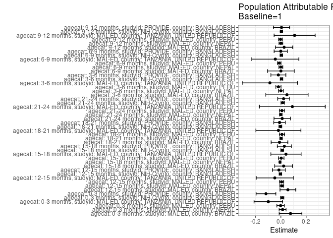

## Results Table

### Parameter: TSM

| agecat | studyid | country | intervention_level | baseline_level | estimate | ci_lower | ci_upper |
| --- | --- | --- | --- | --- | --- | --- | --- |
| 0-3 months | MAL-ED | BRAZIL | 1 | NA | 1.0020168 | 0.9162690 | 1.0877647 |
| 0-3 months | MAL-ED | BRAZIL | 0 | NA | 1.0895809 | 1.0326282 | 1.1465336 |
| 0-3 months | MAL-ED | NEPAL | 1 | NA | 0.9356101 | 0.8856311 | 0.9855891 |
| 0-3 months | MAL-ED | NEPAL | 0 | NA | 1.0152358 | 0.8682613 | 1.1622102 |
| 0-3 months | MAL-ED | PERU | 1 | NA | 0.9347777 | 0.8799373 | 0.9896182 |
| 0-3 months | MAL-ED | PERU | 0 | NA | 0.9242771 | 0.7896659 | 1.0588882 |
| 0-3 months | MAL-ED | TANZANIA, UNITED REPUBLIC OF | 1 | NA | 1.0002689 | 0.8901714 | 1.1103664 |
| 0-3 months | MAL-ED | TANZANIA, UNITED REPUBLIC OF | 0 | NA | 0.8836569 | 0.8111346 | 0.9561791 |
| 0-3 months | NIH-Crypto | BANGLADESH | 1 | NA | 0.8741442 | 0.8549364 | 0.8933520 |
| 0-3 months | NIH-Crypto | BANGLADESH | 0 | NA | 0.8976563 | 0.8754840 | 0.9198286 |
| 0-3 months | PROVIDE | BANGLADESH | 1 | NA | 1.0199951 | 0.9409177 | 1.0990724 |
| 0-3 months | PROVIDE | BANGLADESH | 0 | NA | 0.8990004 | 0.8840689 | 0.9139319 |
| 3-6 months | MAL-ED | BRAZIL | 1 | NA | 0.5454162 | 0.3603331 | 0.7304993 |
| 3-6 months | MAL-ED | BRAZIL | 0 | NA | 0.6004206 | 0.5500764 | 0.6507648 |
| 3-6 months | MAL-ED | NEPAL | 1 | NA | 0.5156939 | 0.4787798 | 0.5526080 |
| 3-6 months | MAL-ED | NEPAL | 0 | NA | 0.5177715 | 0.4115555 | 0.6239874 |
| 3-6 months | MAL-ED | PERU | 1 | NA | 0.5219366 | 0.4637584 | 0.5801148 |
| 3-6 months | MAL-ED | PERU | 0 | NA | 0.4273718 | 0.3638292 | 0.4909145 |
| 3-6 months | MAL-ED | TANZANIA, UNITED REPUBLIC OF | 1 | NA | 0.5378113 | 0.3002548 | 0.7753678 |
| 3-6 months | MAL-ED | TANZANIA, UNITED REPUBLIC OF | 0 | NA | 0.4362014 | 0.3434105 | 0.5289923 |
| 3-6 months | NIH-Crypto | BANGLADESH | 1 | NA | 0.4932351 | 0.4783060 | 0.5081642 |
| 3-6 months | NIH-Crypto | BANGLADESH | 0 | NA | 0.5040094 | 0.4875510 | 0.5204679 |
| 3-6 months | PROVIDE | BANGLADESH | 1 | NA | 0.5089583 | 0.4494359 | 0.5684807 |
| 3-6 months | PROVIDE | BANGLADESH | 0 | NA | 0.4885866 | 0.4752863 | 0.5018868 |
| 6-9 months | MAL-ED | BRAZIL | 1 | NA | 0.3998959 | 0.2858629 | 0.5139289 |
| 6-9 months | MAL-ED | BRAZIL | 0 | NA | 0.4003138 | 0.3587758 | 0.4418519 |
| 6-9 months | MAL-ED | NEPAL | 1 | NA | 0.2685606 | 0.2394796 | 0.2976416 |
| 6-9 months | MAL-ED | NEPAL | 0 | NA | 0.2671924 | 0.1817652 | 0.3526195 |
| 6-9 months | MAL-ED | PERU | 1 | NA | 0.2650023 | 0.2298248 | 0.3001798 |
| 6-9 months | MAL-ED | PERU | 0 | NA | 0.2013177 | 0.1521457 | 0.2504898 |

[output cut: 66 more lines]

### Parameter: E(Y)

| agecat | studyid | country | intervention_level | baseline_level | estimate | ci_lower | ci_upper |
| --- | --- | --- | --- | --- | --- | --- | --- |
| 0-3 months | MAL-ED | BRAZIL | NA | NA | 1.0785291 | 1.0272897 | 1.1297685 |
| 0-3 months | MAL-ED | NEPAL | NA | NA | 0.9493726 | 0.9004043 | 0.9983408 |
| 0-3 months | MAL-ED | PERU | NA | NA | 0.9326347 | 0.8810468 | 0.9842227 |
| 0-3 months | MAL-ED | TANZANIA, UNITED REPUBLIC OF | NA | NA | 0.9007220 | 0.8354879 | 0.9659562 |
| 0-3 months | NIH-Crypto | BANGLADESH | NA | NA | 0.8845220 | 0.8699746 | 0.8990694 |
| 0-3 months | PROVIDE | BANGLADESH | NA | NA | 0.9016472 | 0.8868914 | 0.9164029 |
| 3-6 months | MAL-ED | BRAZIL | NA | NA | 0.5934783 | 0.5435445 | 0.6434121 |
| 3-6 months | MAL-ED | NEPAL | NA | NA | 0.5160486 | 0.4804683 | 0.5516290 |
| 3-6 months | MAL-ED | PERU | NA | NA | 0.5026377 | 0.4533571 | 0.5519182 |
| 3-6 months | MAL-ED | TANZANIA, UNITED REPUBLIC OF | NA | NA | 0.4507171 | 0.3635622 | 0.5378720 |
| 3-6 months | NIH-Crypto | BANGLADESH | NA | NA | 0.4980544 | 0.4869892 | 0.5091196 |
| 3-6 months | PROVIDE | BANGLADESH | NA | NA | 0.4890611 | 0.4760060 | 0.5021163 |
| 6-9 months | MAL-ED | BRAZIL | NA | NA | 0.4002611 | 0.3612162 | 0.4393059 |
| 6-9 months | MAL-ED | NEPAL | NA | NA | 0.2683270 | 0.2401434 | 0.2965106 |
| 6-9 months | MAL-ED | PERU | NA | NA | 0.2520055 | 0.2213895 | 0.2826214 |
| 6-9 months | MAL-ED | TANZANIA, UNITED REPUBLIC OF | NA | NA | 0.2253405 | 0.1374776 | 0.3132034 |
| 6-9 months | NIH-Crypto | BANGLADESH | NA | NA | 0.2675097 | 0.2569518 | 0.2780676 |
| 6-9 months | PROVIDE | BANGLADESH | NA | NA | 0.2491653 | 0.2371134 | 0.2612172 |
| 9-12 months | MAL-ED | BRAZIL | NA | NA | 0.2831198 | 0.2443371 | 0.3219026 |
| 9-12 months | MAL-ED | NEPAL | NA | NA | 0.1905809 | 0.1625784 | 0.2185835 |
| 9-12 months | MAL-ED | PERU | NA | NA | 0.1997749 | 0.1642326 | 0.2353171 |
| 9-12 months | MAL-ED | TANZANIA, UNITED REPUBLIC OF | NA | NA | 0.1329811 | 0.0819697 | 0.1839925 |
| 9-12 months | NIH-Crypto | BANGLADESH | NA | NA | 0.1978449 | 0.1874487 | 0.2082411 |
| 9-12 months | PROVIDE | BANGLADESH | NA | NA | 0.1775316 | 0.1681968 | 0.1868664 |
| 12-15 months | MAL-ED | BRAZIL | NA | NA | 0.2016949 | 0.1703194 | 0.2330704 |
| 12-15 months | MAL-ED | NEPAL | NA | NA | 0.1416418 | 0.1110034 | 0.1722801 |
| 12-15 months | MAL-ED | PERU | NA | NA | 0.1424940 | 0.1030357 | 0.1819523 |
| 12-15 months | MAL-ED | TANZANIA, UNITED REPUBLIC OF | NA | NA | 0.2041939 | 0.1491943 | 0.2591935 |
| 12-15 months | NIH-Crypto | BANGLADESH | NA | NA | 0.1640603 | 0.1535198 | 0.1746008 |
| 12-15 months | PROVIDE | BANGLADESH | NA | NA | 0.1800324 | 0.1683272 | 0.1917375 |
| 15-18 months | MAL-ED | BRAZIL | NA | NA | 0.2121519 | 0.1722209 | 0.2520830 |
| 15-18 months | MAL-ED | NEPAL | NA | NA | 0.1744053 | 0.1523126 | 0.1964979 |
| 15-18 months | MAL-ED | PERU | NA | NA | 0.1396329 | 0.0961677 | 0.1830980 |
| 15-18 months | MAL-ED | TANZANIA, UNITED REPUBLIC OF | NA | NA | 0.1088672 | 0.0551896 | 0.1625448 |
| 15-18 months | NIH-Crypto | BANGLADESH | NA | NA | 0.1611973 | 0.1506617 | 0.1717329 |
| 15-18 months | PROVIDE | BANGLADESH | NA | NA | 0.1563514 | 0.1445823 | 0.1681205 |
| 18-21 months | MAL-ED | BRAZIL | NA | NA | 0.1613623 | 0.1290425 | 0.1936822 |
| 18-21 months | MAL-ED | NEPAL | NA | NA | 0.1854094 | 0.1617682 | 0.2090505 |
| 18-21 months | MAL-ED | PERU | NA | NA | 0.1970640 | 0.1585526 | 0.2355754 |
| 18-21 months | MAL-ED | TANZANIA, UNITED REPUBLIC OF | NA | NA | 0.1748513 | 0.1157560 | 0.2339466 |
| 18-21 months | NIH-Crypto | BANGLADESH | NA | NA | 0.1426609 | 0.1319333 | 0.1533885 |
| 18-21 months | PROVIDE | BANGLADESH | NA | NA | 0.1324882 | 0.1210438 | 0.1439326 |
| 21-24 months | MAL-ED | BRAZIL | NA | NA | 0.1492836 | 0.1183710 | 0.1801961 |
| 21-24 months | MAL-ED | NEPAL | NA | NA | 0.1643936 | 0.1387769 | 0.1900103 |
| 21-24 months | MAL-ED | PERU | NA | NA | 0.1753485 | 0.1374186 | 0.2132784 |
| 21-24 months | MAL-ED | TANZANIA, UNITED REPUBLIC OF | NA | NA | 0.1191438 | 0.0472705 | 0.1910171 |
| 21-24 months | NIH-Crypto | BANGLADESH | NA | NA | 0.1750500 | 0.1624914 | 0.1876087 |
| 21-24 months | PROVIDE | BANGLADESH | NA | NA | 0.1419705 | 0.1305335 | 0.1534075 |

### Parameter: ATE

| agecat | studyid | country | intervention_level | baseline_level | estimate | ci_lower | ci_upper |
| --- | --- | --- | --- | --- | --- | --- | --- |
| 0-3 months | MAL-ED | BRAZIL | 1 | 1 | 0.0000000 | 0.0000000 | 0.0000000 |
| 0-3 months | MAL-ED | BRAZIL | 0 | 1 | 0.0875640 | -0.0153743 | 0.1905024 |
| 0-3 months | MAL-ED | NEPAL | 1 | 1 | 0.0000000 | 0.0000000 | 0.0000000 |
| 0-3 months | MAL-ED | NEPAL | 0 | 1 | 0.0796256 | -0.0756142 | 0.2348654 |
| 0-3 months | MAL-ED | PERU | 1 | 1 | 0.0000000 | 0.0000000 | 0.0000000 |
| 0-3 months | MAL-ED | PERU | 0 | 1 | -0.0105007 | -0.1558541 | 0.1348528 |
| 0-3 months | MAL-ED | TANZANIA, UNITED REPUBLIC OF | 1 | 1 | 0.0000000 | 0.0000000 | 0.0000000 |
| 0-3 months | MAL-ED | TANZANIA, UNITED REPUBLIC OF | 0 | 1 | -0.1166120 | -0.2484488 | 0.0152248 |
| 0-3 months | NIH-Crypto | BANGLADESH | 1 | 1 | 0.0000000 | 0.0000000 | 0.0000000 |
| 0-3 months | NIH-Crypto | BANGLADESH | 0 | 1 | 0.0235120 | -0.0058231 | 0.0528472 |
| 0-3 months | PROVIDE | BANGLADESH | 1 | 1 | 0.0000000 | 0.0000000 | 0.0000000 |
| 0-3 months | PROVIDE | BANGLADESH | 0 | 1 | -0.1209946 | -0.2014693 | -0.0405199 |
| 3-6 months | MAL-ED | BRAZIL | 1 | 1 | 0.0000000 | 0.0000000 | 0.0000000 |
| 3-6 months | MAL-ED | BRAZIL | 0 | 1 | 0.0550044 | -0.1368036 | 0.2468123 |
| 3-6 months | MAL-ED | NEPAL | 1 | 1 | 0.0000000 | 0.0000000 | 0.0000000 |
| 3-6 months | MAL-ED | NEPAL | 0 | 1 | 0.0020775 | -0.1103701 | 0.1145252 |
| 3-6 months | MAL-ED | PERU | 1 | 1 | 0.0000000 | 0.0000000 | 0.0000000 |
| 3-6 months | MAL-ED | PERU | 0 | 1 | -0.0945648 | -0.1807179 | -0.0084116 |
| 3-6 months | MAL-ED | TANZANIA, UNITED REPUBLIC OF | 1 | 1 | 0.0000000 | 0.0000000 | 0.0000000 |
| 3-6 months | MAL-ED | TANZANIA, UNITED REPUBLIC OF | 0 | 1 | -0.1016099 | -0.3566457 | 0.1534259 |
| 3-6 months | NIH-Crypto | BANGLADESH | 1 | 1 | 0.0000000 | 0.0000000 | 0.0000000 |
| 3-6 months | NIH-Crypto | BANGLADESH | 0 | 1 | 0.0107743 | -0.0114463 | 0.0329950 |
| 3-6 months | PROVIDE | BANGLADESH | 1 | 1 | 0.0000000 | 0.0000000 | 0.0000000 |
| 3-6 months | PROVIDE | BANGLADESH | 0 | 1 | -0.0203717 | -0.0813620 | 0.0406186 |
| 6-9 months | MAL-ED | BRAZIL | 1 | 1 | 0.0000000 | 0.0000000 | 0.0000000 |
| 6-9 months | MAL-ED | BRAZIL | 0 | 1 | 0.0004179 | -0.1209449 | 0.1217807 |
| 6-9 months | MAL-ED | NEPAL | 1 | 1 | 0.0000000 | 0.0000000 | 0.0000000 |
| 6-9 months | MAL-ED | NEPAL | 0 | 1 | -0.0013682 | -0.0916096 | 0.0888731 |
| 6-9 months | MAL-ED | PERU | 1 | 1 | 0.0000000 | 0.0000000 | 0.0000000 |
| 6-9 months | MAL-ED | PERU | 0 | 1 | -0.0636846 | -0.1241441 | -0.0032251 |

[output cut: 66 more lines]

### Parameter: PAR

| agecat | studyid | country | intervention_level | baseline_level | estimate | ci_lower | ci_upper |
| --- | --- | --- | --- | --- | --- | --- | --- |
| 0-3 months | MAL-ED | BRAZIL | 1 | NA | 0.0765123 | -0.0136107 | 0.1666352 |
| 0-3 months | MAL-ED | NEPAL | 1 | NA | 0.0137625 | -0.0138683 | 0.0413932 |
| 0-3 months | MAL-ED | PERU | 1 | NA | -0.0021430 | -0.0318311 | 0.0275451 |
| 0-3 months | MAL-ED | TANZANIA, UNITED REPUBLIC OF | 1 | NA | -0.0995468 | -0.2128129 | 0.0137193 |
| 0-3 months | NIH-Crypto | BANGLADESH | 1 | NA | 0.0103777 | -0.0025981 | 0.0233536 |
| 0-3 months | PROVIDE | BANGLADESH | 1 | NA | -0.1183479 | -0.1968227 | -0.0398730 |
| 3-6 months | MAL-ED | BRAZIL | 1 | NA | 0.0480621 | -0.1195746 | 0.2156988 |
| 3-6 months | MAL-ED | NEPAL | 1 | NA | 0.0003547 | -0.0188444 | 0.0195538 |
| 3-6 months | MAL-ED | PERU | 1 | NA | -0.0192989 | -0.0399238 | 0.0013259 |
| 3-6 months | MAL-ED | TANZANIA, UNITED REPUBLIC OF | 1 | NA | -0.0870942 | -0.3059671 | 0.1317786 |
| 3-6 months | NIH-Crypto | BANGLADESH | 1 | NA | 0.0048193 | -0.0051278 | 0.0147664 |
| 3-6 months | PROVIDE | BANGLADESH | 1 | NA | -0.0198972 | -0.0793632 | 0.0395689 |
| 6-9 months | MAL-ED | BRAZIL | 1 | NA | 0.0003652 | -0.1056800 | 0.1064103 |
| 6-9 months | MAL-ED | NEPAL | 1 | NA | -0.0002336 | -0.0156411 | 0.0151739 |
| 6-9 months | MAL-ED | PERU | 1 | NA | -0.0129969 | -0.0273135 | 0.0013197 |
| 6-9 months | MAL-ED | TANZANIA, UNITED REPUBLIC OF | 1 | NA | -0.0440499 | -0.2307706 | 0.1426708 |
| 6-9 months | NIH-Crypto | BANGLADESH | 1 | NA | 0.0035990 | -0.0061263 | 0.0133243 |
| 6-9 months | PROVIDE | BANGLADESH | 1 | NA | -0.0010245 | -0.0535674 | 0.0515183 |
| 9-12 months | MAL-ED | BRAZIL | 1 | NA | 0.0258300 | -0.0426185 | 0.0942784 |
| 9-12 months | MAL-ED | NEPAL | 1 | NA | -0.0000942 | -0.0148344 | 0.0146459 |
| 9-12 months | MAL-ED | PERU | 1 | NA | -0.0029229 | -0.0176111 | 0.0117653 |
| 9-12 months | MAL-ED | TANZANIA, UNITED REPUBLIC OF | 1 | NA | 0.1087821 | -0.0538143 | 0.2713786 |
| 9-12 months | NIH-Crypto | BANGLADESH | 1 | NA | 0.0040633 | -0.0054412 | 0.0135678 |
| 9-12 months | PROVIDE | BANGLADESH | 1 | NA | 0.0050426 | -0.0591242 | 0.0692094 |
| 12-15 months | MAL-ED | BRAZIL | 1 | NA | 0.0554860 | -0.0070670 | 0.1180391 |
| 12-15 months | MAL-ED | NEPAL | 1 | NA | 0.0070447 | -0.0079267 | 0.0220162 |
| 12-15 months | MAL-ED | PERU | 1 | NA | 0.0053758 | -0.0112578 | 0.0220095 |
| 12-15 months | MAL-ED | TANZANIA, UNITED REPUBLIC OF | 1 | NA | -0.0483574 | -0.1955965 | 0.0988818 |
| 12-15 months | NIH-Crypto | BANGLADESH | 1 | NA | -0.0038080 | -0.0136416 | 0.0060257 |
| 12-15 months | PROVIDE | BANGLADESH | 1 | NA | -0.0157167 | -0.0666858 | 0.0352525 |
| 15-18 months | MAL-ED | BRAZIL | 1 | NA | 0.0216584 | -0.0489071 | 0.0922239 |
| 15-18 months | MAL-ED | NEPAL | 1 | NA | -0.0066478 | -0.0136891 | 0.0003936 |
| 15-18 months | MAL-ED | PERU | 1 | NA | 0.0028647 | -0.0193216 | 0.0250510 |
| 15-18 months | MAL-ED | TANZANIA, UNITED REPUBLIC OF | 1 | NA | 0.0404729 | -0.0795337 | 0.1604795 |
| 15-18 months | NIH-Crypto | BANGLADESH | 1 | NA | 0.0105714 | 0.0001156 | 0.0210271 |
| 15-18 months | PROVIDE | BANGLADESH | 1 | NA | 0.0274437 | -0.0283627 | 0.0832500 |
| 18-21 months | MAL-ED | BRAZIL | 1 | NA | -0.0110518 | -0.0773094 | 0.0552058 |
| 18-21 months | MAL-ED | NEPAL | 1 | NA | 0.0017274 | -0.0079409 | 0.0113956 |
| 18-21 months | MAL-ED | PERU | 1 | NA | 0.0088029 | -0.0116542 | 0.0292600 |
| 18-21 months | MAL-ED | TANZANIA, UNITED REPUBLIC OF | 1 | NA | -0.0194905 | -0.1980579 | 0.1590769 |
| 18-21 months | NIH-Crypto | BANGLADESH | 1 | NA | -0.0041368 | -0.0151090 | 0.0068354 |
| 18-21 months | PROVIDE | BANGLADESH | 1 | NA | -0.0105757 | -0.0563918 | 0.0352404 |
| 21-24 months | MAL-ED | BRAZIL | 1 | NA | 0.0106142 | -0.0545485 | 0.0757769 |
| 21-24 months | MAL-ED | NEPAL | 1 | NA | -0.0002849 | -0.0107214 | 0.0101515 |
| 21-24 months | MAL-ED | PERU | 1 | NA | 0.0085267 | -0.0110943 | 0.0281477 |
| 21-24 months | MAL-ED | TANZANIA, UNITED REPUBLIC OF | 1 | NA | 0.0907535 | -0.1700304 | 0.3515373 |
| 21-24 months | NIH-Crypto | BANGLADESH | 1 | NA | 0.0148817 | 0.0012850 | 0.0284784 |
| 21-24 months | PROVIDE | BANGLADESH | 1 | NA | 0.0213343 | -0.0249374 | 0.0676059 |